# AMEC 2026 | Coding Workshop

Writing Reproducible  
Research with R

Mirindi Kabangu, BS

mkabangu@iu.edu

Indiana University School of Medicine

## Instructor

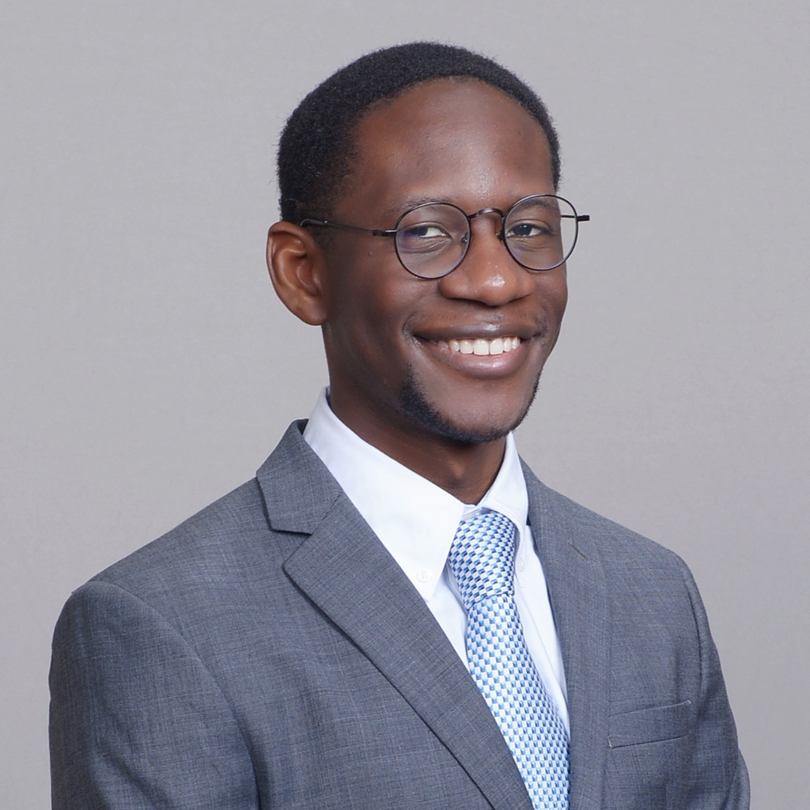

Mirindi Kabangu

- MD Candidate, Indiana University School of Medicine
- Member, Student National Medical Association
- Research interests: clinical data science, health equity
- Contact: mkabangu@iu.edu | mkabangu@uiowa.edu

[figure not shown]

[figure not shown]

[figure not shown]

[figure not shown]

## By the end of this hour…

You will have **written a paper**.

- Not metaphorically — you will have produced the actual outputs that go into a manuscript
- A **Table 1** describing your patient population
- **Figures** showing your key results
- **Statistical comparisons** between treatment arms
- And you’ll know exactly what R line produced each one

**No installation. No prior R experience required.**

Everything runs live in your browser. You are already set up.

# You Just Got an Email from Your PI

## 📧 From: Your PI

> *“I’m attaching de-identified data from our phase II RCT — 200 patients randomized to Drug A vs. Drug B. We’re submitting to JCO next month.*

> *I need:* - *Table 1 comparing baseline characteristics by treatment arm* - *A figure showing tumor response rates by treatment* - *A figure showing marker levels by grade and treatment* - *p-values throughout*

> *Can you have a draft by end of week?*

> *— PI”*

You open your laptop. Let’s go.

# Section 1: Meet Your Data

## Step 1: Look at what you’ve got

Before you write a single word of a paper, you need to know your data.

In R, that’s two lines:

```r
glimpse(trial)   # column names, types, first values
head(trial)      # first 6 rows
```

**Note**

`trial` is a real-format RCT dataset from the `gtsummary` package. 200 patients. 6 variables. Two treatment arms: Drug A and Drug B.

## 🖥️ Try It: Explore the Data

Run the code below. Then swap `glimpse` for `head` and run it again. What variables do you see?

## The Paper Line This Produces

Every time you run code today, ask: **what would I write in the paper?**

That sentence used to require you to count rows manually in Excel. Now it takes 1 line of R.

# Section 2: Describing Your Patients

## What goes in Table 1?

Table 1 is the “who are these patients?” table. It appears in nearly every clinical paper ever published.

- **Rows:** your variables (age, stage, grade, marker, response)
- **Columns:** your treatment groups + a Total column
- **Cells:** mean ± SD for continuous variables, n (%) for categorical
- **Last column:** p-values testing whether groups are balanced at baseline

In Excel: calculate each cell manually. Choose each test manually. Format manually.

In R: **one function.**

## Building Table 1 Step by Step

```r
trial |> tbl_summary()
```

That’s it. But we can make it publication-ready in 6 lines total.

We’ll build it one line at a time — **you’ll see every decision.**

## Building Table 1

```r
trial |>
  # Step 1: select variables for the table
  select(trt, age, marker, stage, grade, response) |>
  tbl_summary()
```

| **Characteristic** | **N = 200**<sup>1</sup> |
| --- | --- |
| Chemotherapy Treatment |  |
| Drug A | 98 (49%) |
| Drug B | 102 (51%) |
| Age | 47 (38, 57) |
| Unknown | 11 |
| Marker Level (ng/mL) | 0.64 (0.22, 1.41) |
| Unknown | 10 |
| T Stage |  |
| T1 | 53 (27%) |
| T2 | 54 (27%) |
| T3 | 43 (22%) |
| T4 | 50 (25%) |
| Grade |  |
| I | 68 (34%) |
| II | 68 (34%) |
| III | 64 (32%) |
| Tumor Response | 61 (32%) |
| Unknown | 7 |

<sup>1</sup> n (%); Median (Q1, Q3)

## Building Table 1

```r
trial |>
  # Step 1: select variables for the table
  select(trt, age, marker, stage, grade, response) |>
  tbl_summary(
    # Step 2: split by treatment arm
    by = trt
  )
```

| **Characteristic** | **Drug A** N = 98<sup>1</sup> | **Drug B** N = 102<sup>1</sup> |
| --- | --- | --- |
| Age | 46 (37, 60) | 48 (39, 56) |
| Unknown | 7 | 4 |
| Marker Level (ng/mL) | 0.84 (0.23, 1.60) | 0.52 (0.18, 1.21) |
| Unknown | 6 | 4 |
| T Stage |  |  |
| T1 | 28 (29%) | 25 (25%) |
| T2 | 25 (26%) | 29 (28%) |
| T3 | 22 (22%) | 21 (21%) |
| T4 | 23 (23%) | 27 (26%) |
| Grade |  |  |
| I | 35 (36%) | 33 (32%) |
| II | 32 (33%) | 36 (35%) |
| III | 31 (32%) | 33 (32%) |
| Tumor Response | 28 (29%) | 33 (34%) |
| Unknown | 3 | 4 |

<sup>1</sup> Median (Q1, Q3); n (%)

## Building Table 1

```r
trial |>
  # Step 1: select variables for the table
  select(trt, age, marker, stage, grade, response) |>
  tbl_summary(
    # Step 2: split by treatment arm
    by = trt,
    # Step 3: report mean ± SD for continuous variables
    statistic = list(
      all_continuous() ~ "{mean} ({sd})",
      all_categorical() ~ "{n} ({p}%)"
    )
  )
```

| **Characteristic** | **Drug A** N = 98<sup>1</sup> | **Drug B** N = 102<sup>1</sup> |
| --- | --- | --- |
| Age | 47 (15) | 47 (14) |
| Unknown | 7 | 4 |
| Marker Level (ng/mL) | 1.02 (0.89) | 0.82 (0.83) |
| Unknown | 6 | 4 |
| T Stage |  |  |
| T1 | 28 (29%) | 25 (25%) |
| T2 | 25 (26%) | 29 (28%) |
| T3 | 22 (22%) | 21 (21%) |
| T4 | 23 (23%) | 27 (26%) |
| Grade |  |  |
| I | 35 (36%) | 33 (32%) |
| II | 32 (33%) | 36 (35%) |
| III | 31 (32%) | 33 (32%) |
| Tumor Response | 28 (29%) | 33 (34%) |
| Unknown | 3 | 4 |

<sup>1</sup> Mean (SD); n (%)

## Building Table 1

```r
trial |>
  # Step 1: select variables for the table
  select(trt, age, marker, stage, grade, response) |>
  tbl_summary(
    # Step 2: split by treatment arm
    by = trt,
    # Step 3: report mean ± SD for continuous variables
    statistic = list(
      all_continuous() ~ "{mean} ({sd})",
      all_categorical() ~ "{n} ({p}%)"
    )
  ) |>
  # Step 4: add p-values (auto test selection)
  add_p()
```

| **Characteristic** | **Drug A** N = 98<sup>1</sup> | **Drug B** N = 102<sup>1</sup> | **p-value**<sup>2</sup> |
| --- | --- | --- | --- |
| Age | 47 (15) | 47 (14) | 0.7 |
| Unknown | 7 | 4 |  |
| Marker Level (ng/mL) | 1.02 (0.89) | 0.82 (0.83) | 0.085 |
| Unknown | 6 | 4 |  |
| T Stage |  |  | 0.9 |
| T1 | 28 (29%) | 25 (25%) |  |
| T2 | 25 (26%) | 29 (28%) |  |
| T3 | 22 (22%) | 21 (21%) |  |
| T4 | 23 (23%) | 27 (26%) |  |
| Grade |  |  | 0.9 |
| I | 35 (36%) | 33 (32%) |  |
| II | 32 (33%) | 36 (35%) |  |
| III | 31 (32%) | 33 (32%) |  |
| Tumor Response | 28 (29%) | 33 (34%) | 0.5 |
| Unknown | 3 | 4 |  |

<sup>1</sup> Mean (SD); n (%)  
<sup>2</sup> Wilcoxon rank sum test; Pearson’s Chi-squared test

## Building Table 1

```r
trial |>
  # Step 1: select variables for the table
  select(trt, age, marker, stage, grade, response) |>
  tbl_summary(
    # Step 2: split by treatment arm
    by = trt,
    # Step 3: report mean ± SD for continuous variables
    statistic = list(
      all_continuous() ~ "{mean} ({sd})",
      all_categorical() ~ "{n} ({p}%)"
    )
  ) |>
  # Step 4: add p-values (auto test selection)
  add_p() |>
  # Step 5: add overall column + polish labels
  add_overall() |>
  bold_labels() |>
  modify_header(label = "**Characteristic**")
```

| **Characteristic** | **Overall** N = 200<sup>1</sup> | **Drug A** N = 98<sup>1</sup> | **Drug B** N = 102<sup>1</sup> | **p-value**<sup>2</sup> |
| --- | --- | --- | --- | --- |
| Age | 47 (14) | 47 (15) | 47 (14) | 0.7 |
| Unknown | 11 | 7 | 4 |  |
| Marker Level (ng/mL) | 0.92 (0.86) | 1.02 (0.89) | 0.82 (0.83) | 0.085 |
| Unknown | 10 | 6 | 4 |  |
| T Stage |  |  |  | 0.9 |
| T1 | 53 (27%) | 28 (29%) | 25 (25%) |  |
| T2 | 54 (27%) | 25 (26%) | 29 (28%) |  |
| T3 | 43 (22%) | 22 (22%) | 21 (21%) |  |
| T4 | 50 (25%) | 23 (23%) | 27 (26%) |  |
| Grade |  |  |  | 0.9 |
| I | 68 (34%) | 35 (36%) | 33 (32%) |  |
| II | 68 (34%) | 32 (33%) | 36 (35%) |  |
| III | 64 (32%) | 31 (32%) | 33 (32%) |  |
| Tumor Response | 61 (32%) | 28 (29%) | 33 (34%) | 0.5 |
| Unknown | 7 | 3 | 4 |  |

<sup>1</sup> Mean (SD); n (%)  
<sup>2</sup> Wilcoxon rank sum test; Pearson’s Chi-squared test

## What the Paper Says

**That paragraph took 5 minutes and 6 lines of R.**

In Excel it would have been 30 minutes of copy-pasting, formula-writing, and manual formatting — and you’d have to redo it if a patient was excluded.

## 🖥️ Your Turn: Reproduce Table 1

Fill in the blanks to reproduce the table. The variable list and label are already there — you just need the `by` argument and `add_p()`.

# Section 3: Showing Your Results

## What goes in the Results figures?

Your PI asked for two figures:

1. **Treatment response rates** by arm — *“Did Drug A or Drug B work better?”*
2. **Marker levels** by grade and treatment — *“Does the biomarker behave differently across subgroups?”*

Both are answered with `ggplot2`. The grammar is always:

```r
data |>
  ggplot(aes(x = ..., y = ..., fill = ...)) +
  geom_*()
```

## Figure 1: Treatment Response Rates

```r
trial |>
  group_by(trt) |>
  # Step 1: calculate response rate per arm
  summarize(
    response_rate = mean(response, na.rm = TRUE)
  )
```

```
# A tibble: 2 × 2
  trt    response_rate
  <chr>          <dbl>
1 Drug A         0.295
2 Drug B         0.337
```

## Figure 1: Treatment Response Rates

[figure not shown]

Figure 1

```r
trial |>
  group_by(trt) |>
  # Step 1: calculate response rate per arm
  summarize(
    response_rate = mean(response, na.rm = TRUE)
  ) |>
  # Step 2: pipe directly into ggplot
  ggplot(aes(x = trt, y = response_rate, fill = trt))
```

## Figure 1: Treatment Response Rates

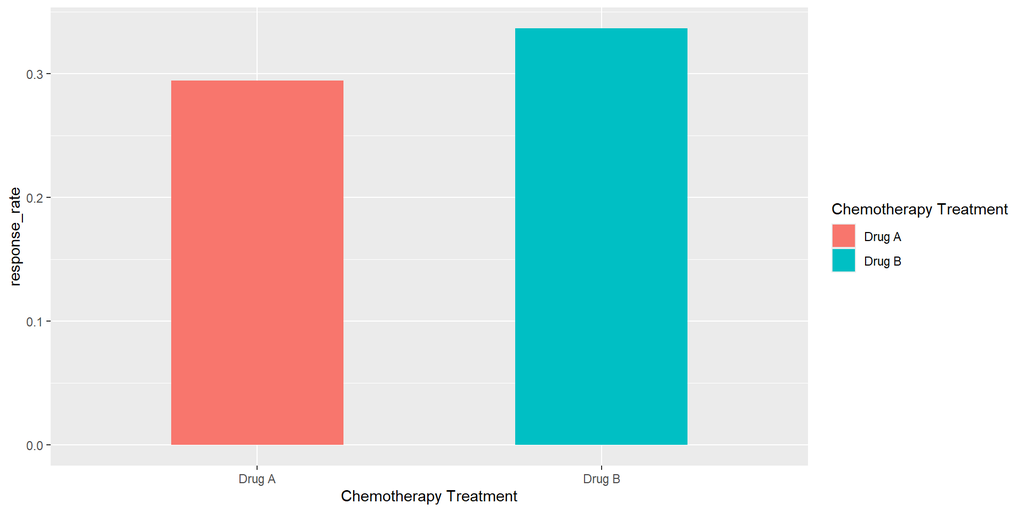

Figure 2

```r
trial |>
  group_by(trt) |>
  # Step 1: calculate response rate per arm
  summarize(
    response_rate = mean(response, na.rm = TRUE)
  ) |>
  # Step 2: pipe directly into ggplot
  ggplot(aes(x = trt, y = response_rate, fill = trt)) +
  # Step 3: add bars
  geom_col(width = 0.5)
```

## Figure 1: Treatment Response Rates

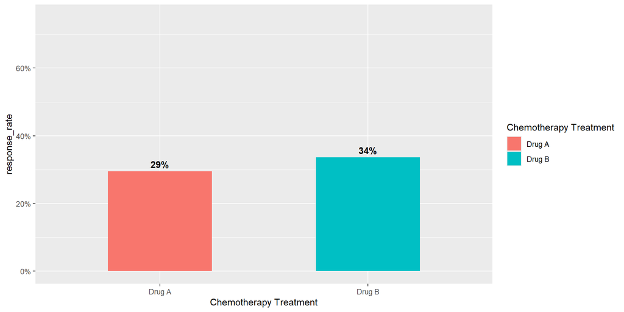

Figure 3

```r
trial |>
  group_by(trt) |>
  # Step 1: calculate response rate per arm
  summarize(
    response_rate = mean(response, na.rm = TRUE)
  ) |>
  # Step 2: pipe directly into ggplot
  ggplot(aes(x = trt, y = response_rate, fill = trt)) +
  # Step 3: add bars
  geom_col(width = 0.5) +
  # Step 4: convert to % and add labels
  geom_text(
    aes(label = scales::percent(response_rate, accuracy = 1)),
    vjust = -0.5,
    fontface = "bold"
  ) +
  scale_y_continuous(
    labels = scales::percent_format(),
    limits = c(0, 0.75)
  )
```

## Figure 1: Treatment Response Rates

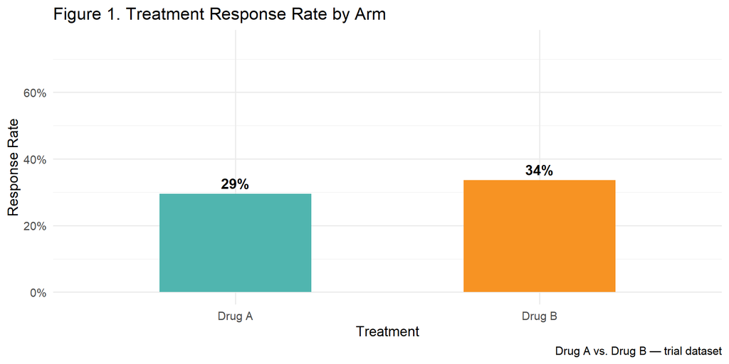

Figure 4

```r
trial |>
  group_by(trt) |>
  # Step 1: calculate response rate per arm
  summarize(
    response_rate = mean(response, na.rm = TRUE)
  ) |>
  # Step 2: pipe directly into ggplot
  ggplot(aes(x = trt, y = response_rate, fill = trt)) +
  # Step 3: add bars
  geom_col(width = 0.5) +
  # Step 4: convert to % and add labels
  geom_text(
    aes(label = scales::percent(response_rate, accuracy = 1)),
    vjust = -0.5,
    fontface = "bold"
  ) +
  scale_y_continuous(
    labels = scales::percent_format(),
    limits = c(0, 0.75)
  ) +
  # Step 5: publication-ready theme and labels
  scale_fill_manual(values = c("#50B5AF", "#F79323")) +
  labs(
    title = "Figure 1. Treatment Response Rate by Arm",
    x = "Treatment",
    y = "Response Rate",
    caption = "Drug A vs. Drug B — trial dataset"
  ) +
  theme_minimal(base_size = 14) +
  theme(legend.position = "none")
```

## What the Paper Says

**The figure does the heavy lifting.**

A reader scanning your paper sees that bar chart before they read a single word of Results. Make it clear and labeled — `ggplot2` just did that for you automatically.

## Figure 2: Marker Levels by Grade and Treatment

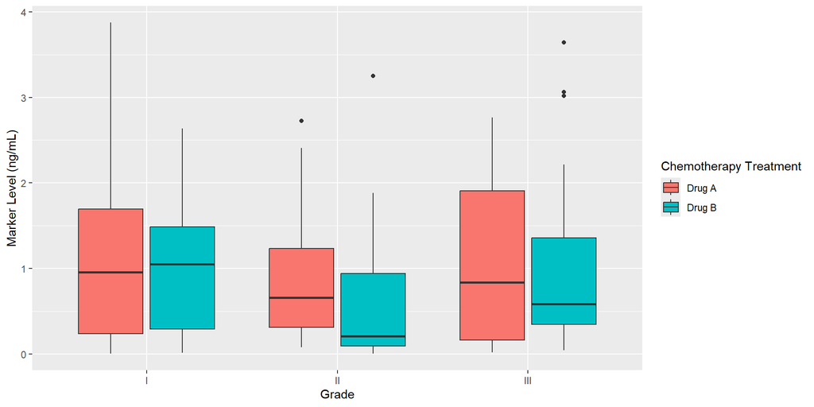

Figure 5

```r
trial |>
  ggplot(aes(x = grade, y = marker, fill = trt)) +
  # Step 1: raw marker data by treatment
  geom_boxplot()
```

## Figure 2: Marker Levels by Grade and Treatment

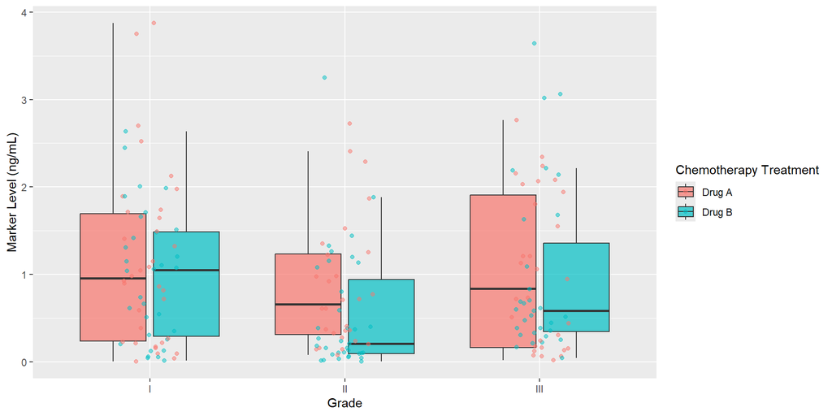

Figure 6

```r
trial |>
  ggplot(aes(x = grade, y = marker, fill = trt)) +
  # Step 1: raw marker data by treatment
  geom_boxplot(outlier.shape = NA, alpha = 0.7) +
  # Step 2: add individual data points
  geom_jitter(
    aes(color = trt),
    width = 0.15,
    alpha = 0.5,
    size = 1.5
  )
```

## Figure 2: Marker Levels by Grade and Treatment

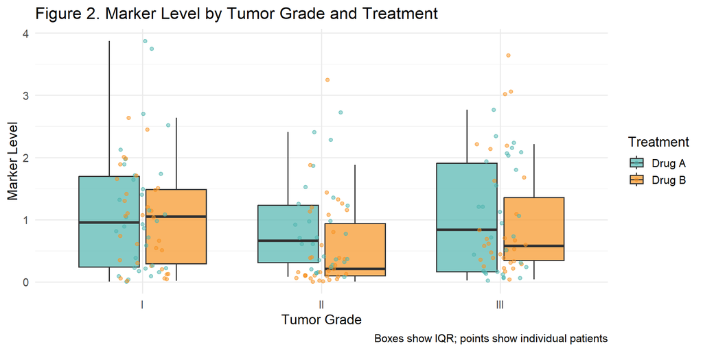

Figure 7

```r
trial |>
  ggplot(aes(x = grade, y = marker, fill = trt)) +
  # Step 1: raw marker data by treatment
  geom_boxplot(outlier.shape = NA, alpha = 0.7) +
  # Step 2: add individual data points
  geom_jitter(
    aes(color = trt),
    width = 0.15,
    alpha = 0.5,
    size = 1.5
  ) +
  # Step 3: publication-ready polish
  scale_fill_manual(values = c("#50B5AF", "#F79323")) +
  scale_color_manual(values = c("#50B5AF", "#F79323")) +
  labs(
    title = "Figure 2. Marker Level by Tumor Grade and Treatment",
    x = "Tumor Grade",
    y = "Marker Level",
    fill = "Treatment",
    color = "Treatment",
    caption = "Boxes show IQR; points show individual patients"
  ) +
  theme_minimal(base_size = 14)
```

## What the Paper Says

**You didn’t touch a formula.**

No `=STDEV()`. No pivot table. No manually filtering by grade. One `ggplot` call split the data, colored it by group, and showed you the distribution — automatically.

## 🖥️ Your Turn: Build Figure 2 from Scratch

Using `trial`, make a boxplot of `marker` levels by `stage` (not grade this time), filled by `trt`. Add axis labels and a title.

*Hint: `geom_boxplot(aes(x = stage, y = marker, fill = trt))`*

# Section 4: The Numbers Behind the Story

## What “analysis” means in a clinical paper

You’ve described the data (Table 1) and shown it visually (Figures 1–2).

Now you need to **formally answer the research question**:

> *“Is Drug A more effective than Drug B?”*
- A **chi-square test** on response rate (categorical outcome)
- A **group comparison** of marker levels by treatment
- These are the p-values that go in your Results section

## Formal Test: Response Rate

```r
# Chi-square: response rate by treatment arm
trial |>
  select(trt, response) |>
  tbl_summary(
    by = trt,
    statistic = all_categorical() ~ "{n} ({p}%)",
    label = response ~ "Treatment Response"
  ) |>
  add_p() |>
  bold_labels()
```

| **Characteristic** | **Drug A** N = 98<sup>1</sup> | **Drug B** N = 102<sup>1</sup> | **p-value**<sup>2</sup> |
| --- | --- | --- | --- |
| Treatment Response | 28 (29%) | 33 (34%) | 0.5 |
| Unknown | 3 | 4 |  |

<sup>1</sup> n (%)  
<sup>2</sup> Pearson’s Chi-squared test

## Formal Test: Marker Levels

```r
# t-test: marker level by treatment arm
trial |>
  select(trt, marker) |>
  tbl_summary(
    by = trt,
    statistic = all_continuous() ~ "{mean} ({sd})",
    label = marker ~ "Marker Level"
  ) |>
  add_p() |>
  bold_labels()
```

| **Characteristic** | **Drug A** N = 98<sup>1</sup> | **Drug B** N = 102<sup>1</sup> | **p-value**<sup>2</sup> |
| --- | --- | --- | --- |
| Marker Level | 1.02 (0.89) | 0.82 (0.83) | 0.085 |
| Unknown | 6 | 4 |  |

<sup>1</sup> Mean (SD)  
<sup>2</sup> Wilcoxon rank sum test

## Full Results Table

```r
# Combine into one clean results table
trial |>
  select(trt, response, marker, grade, stage) |>
  tbl_summary(
    by = trt,
    statistic = list(
      all_continuous() ~ "{mean} ({sd})",
      all_categorical() ~ "{n} ({p}%)"
    ),
    label = list(
      response ~ "Treatment Response",
      marker ~ "Marker Level",
      grade ~ "Tumor Grade",
      stage ~ "T Stage"
    )
  ) |>
  add_p() |>
  add_overall() |>
  bold_labels() |>
  modify_header(label = "**Outcome / Variable**")
```

| **Outcome / Variable** | **Overall** N = 200<sup>1</sup> | **Drug A** N = 98<sup>1</sup> | **Drug B** N = 102<sup>1</sup> | **p-value**<sup>2</sup> |
| --- | --- | --- | --- | --- |
| Treatment Response | 61 (32%) | 28 (29%) | 33 (34%) | 0.5 |
| Unknown | 7 | 3 | 4 |  |
| Marker Level | 0.92 (0.86) | 1.02 (0.89) | 0.82 (0.83) | 0.085 |
| Unknown | 10 | 6 | 4 |  |
| Tumor Grade |  |  |  | 0.9 |
| I | 68 (34%) | 35 (36%) | 33 (32%) |  |
| II | 68 (34%) | 32 (33%) | 36 (35%) |  |
| III | 64 (32%) | 31 (32%) | 33 (32%) |  |
| T Stage |  |  |  | 0.9 |
| T1 | 53 (27%) | 28 (29%) | 25 (25%) |  |
| T2 | 54 (27%) | 25 (26%) | 29 (28%) |  |
| T3 | 43 (22%) | 22 (22%) | 21 (21%) |  |
| T4 | 50 (25%) | 23 (23%) | 27 (26%) |  |

<sup>1</sup> n (%); Mean (SD)  
<sup>2</sup> Pearson’s Chi-squared test; Wilcoxon rank sum test

## What the Paper Says

**What does this tell us about the trial?**

Neither the response rate nor the biomarker differed significantly between arms. In a real paper, this shapes your Discussion — Drug B showed a numerically higher response rate but the study may have been underpowered to detect a difference.

## 🖥️ Your Turn: Grade-Stratified Analysis

Filter for **Grade III patients only**, then build a `tbl_summary()` comparing `response` and `marker` by `trt`, with p-values.

*This is a subgroup analysis — one of the most common requests in clinical research.*

# Section 5: Conclusions — What Does It All Mean?

## The conclusion follows from the output

You’ve now produced:

- ✅ **Table 1** — patients were balanced at baseline
- ✅ **Figure 1** — response rates by treatment arm
- ✅ **Figure 2** — marker levels by grade and treatment
- ✅ **Analysis table** — formal p-values for all comparisons

All of it came from one dataset. All of it is reproducible. If the data changes — one row excluded, one variable added — **you re-run the script and every table and figure updates automatically.**

## 🖥️ Boss Level: Write Your Own Analysis

No blanks. No hints. Your PI just emailed back:

> *“Can you also look at whether marker level predicts response, stratified by grade? Just a quick summary — whatever you think makes sense.”*

Use `trial`. Use any combination of `filter()`, `group_by()`, `tbl_summary()`, or `ggplot()`. There is no single right answer.

# One More Thing: Reproducible Prose

## The hidden reproducibility problem

Tables and figures update when you re-run. But what about the **sentences in your paper**?

This is the most common way reproducibility breaks down in practice:

> *“The mean age was **47** years…”*

Six months later, you exclude 3 patients. You re-run R. The tables update. But that **47** in your Methods section? Still there. **Manually. Wrong.**

**Hard-coded numbers in prose are a reproducibility leak.**

Every time you type a number into a sentence, you create a place where the paper and the data can silently disagree.

## The fix: inline R code

In a Quarto document, you can embed live R expressions directly inside your prose using `` `r` ``:

```markdown
The mean age was ` r round(mean(trial$age, na.rm = TRUE), 1)` years
(SD ` r round(sd(trial$age, na.rm = TRUE), 1)`).
```

When the document renders, that becomes:

> *“The mean age was 47.2 years (SD 14.3).”*

Re-run on updated data? The sentence updates **automatically**. The number in the prose and the number in the table are guaranteed to match — they come from the same computation.

## Your entire Results section, reproducible

```markdown
A total of ` r nrow(trial)` patients were enrolled, randomized to
Drug A (n = ` r sum(trial$trt == "Drug A")`) or
Drug B (n = ` r sum(trial$trt == "Drug B")`).
```

## Your entire Results section, reproducible

```markdown
A total of ` r nrow(trial)` patients were enrolled, randomized to
Drug A (n = ` r sum(trial$trt == "Drug A")`) or
Drug B (n = ` r sum(trial$trt == "Drug B")`).

The response rate was
` r scales::percent(mean(trial$response[trial$trt=="Drug A"], na.rm=TRUE), accuracy=1)`
in the Drug A arm vs.
` r scales::percent(mean(trial$response[trial$trt=="Drug B"], na.rm=TRUE), accuracy=1)`
in the Drug B arm.
```

## Your entire Results section, reproducible

```markdown
A total of ` r nrow(trial)` patients were enrolled...
The response rate was ` r drug_a_resp` vs. ` r drug_b_resp`...
```

**The full power of reproducible research.**

Change the dataset → re-render the document → **every number in every sentence updates**.

Tables ✅ Figures ✅ Prose ✅

This is what separates a reproducible paper from a paper that just happens to have code attached.

# Wrapping Up: The Paper You Just Wrote

## Look what you built in 60 minutes

- 📋 **Table 1** — baseline characteristics, mean ± SD, p-values, formatted for submission
- 📊 **Figure 1** — treatment response rate bar chart, percent-labeled, publication-ready
- 📦 **Figure 2** — marker levels by grade and treatment, boxplot with jittered points
- 🔬 **Results table** — formal group comparisons across all outcomes
- 🔍 **Subgroup analysis** — Grade III patients, stratified by treatment
- ✍️ **Reproducible prose** — every number in your sentences tied to the data with `` `r ` ``

Update the data → re-render → **everything updates**. Tables, figures, and the sentences that describe them.

## Why this matters for your career

- NIH and major journals now **require code and data sharing** at publication
- Hospital analytics teams are moving to **R and Python at scale** — Excel breaks at 100K rows
- A student who can produce a clean Table 1 and two figures in an afternoon is **genuinely useful** to a PI from day one
- The skills you used today transfer directly to **your own research data**

## Your first step after today

**Tonight:** Go to posit.cloud — free RStudio in your browser. Create a project.

**This week:** Run `glimpse()` on any dataset you’ve been meaning to analyze. Paste it into ChatGPT or Claude and say “help me write a tbl_summary for this.” You’ll have a Table 1 draft in 10 minutes.

**This month:** Replace one Excel analysis with R. Just one. That’s the habit.

## Where to go next

| Resource | What it’s for |
| --- | --- |
| r4ds.hadley.nz | Free textbook |
| posit.cloud | Free RStudio in your browser |
| [medicaldata](https://higgi13425.github.io/medicaldata/) | Free clinical datasets |
| [rmrwr](https://bookdown.org/pdr_higgins/rmrwr/) | Free clinical r textbook |
| [DART Program](https://arcus.github.io/education_modules/example_pathways#:~:text=Pathway%204%3A%20Analysis%20in%20R) | Free hands-on tutorials |

## Thank you

Resources:

- Slides: [github.com/MKabangu/talks](https://github.com/MKabangu/talks/tree/main/2026-snma-coding-workshop)
- Website: [mirindikabangu.github.io](https://mirindikabangu.github.io/mirindikabangu)
- LinkedIn [linkedin.com/in/mirindikabangu](https://www.linkedin.com/in/mirindikabangu/)

**One last thing**

If you open R this week and run `glimpse()` on your own data — even once — this session will have done its job.